# Slide 1: Title Slide

# Ford GoBike Data Exploration

# Subtitle: Summary of Findings and Insights

# Author: [Samir Sadikovic]

# Date: [07.07.2024]

|  | duration_sec | start_time | end_time | start_station_id | start_station_name | start_station_latitude | start_station_longitude | end_station_id | end_station_name | end_station_latitude | end_station_longitude | bike_id | user_type | member_birth_year | member_gender | bike_share_for_all_trip |
| --- | --- | --- | --- | --- | --- | --- | --- | --- | --- | --- | --- | --- | --- | --- | --- | --- |
| 0 | 52185 | 2019-02-28 17:32:10.1450 | 2019-03-01 08:01:55.9750 | 21.0 | Montgomery St BART Station (Market St at 2nd St) | 37.789625 | -122.400811 | 13.0 | Commercial St at Montgomery St | 37.794231 | -122.402923 | 4902 | Customer | 1984.0 | Male | No |
| 1 | 42521 | 2019-02-28 18:53:21.7890 | 2019-03-01 06:42:03.0560 | 23.0 | The Embarcadero at Steuart St | 37.791464 | -122.391034 | 81.0 | Berry St at 4th St | 37.775880 | -122.393170 | 2535 | Customer | NaN | NaN | No |
| 2 | 61854 | 2019-02-28 12:13:13.2180 | 2019-03-01 05:24:08.1460 | 86.0 | Market St at Dolores St | 37.769305 | -122.426826 | 3.0 | Powell St BART Station (Market St at 4th St) | 37.786375 | -122.404904 | 5905 | Customer | 1972.0 | Male | No |
| 3 | 36490 | 2019-02-28 17:54:26.0100 | 2019-03-01 04:02:36.8420 | 375.0 | Grove St at Masonic Ave | 37.774836 | -122.446546 | 70.0 | Central Ave at Fell St | 37.773311 | -122.444293 | 6638 | Subscriber | 1989.0 | Other | No |
| 4 | 1585 | 2019-02-28 23:54:18.5490 | 2019-03-01 00:20:44.0740 | 7.0 | Frank H Ogawa Plaza | 37.804562 | -122.271738 | 222.0 | 10th Ave at E 15th St | 37.792714 | -122.248780 | 4898 | Subscriber | 1974.0 | Male | Yes |

Slide 4: Univariate Exploration

### Visualization 1: Distribution of Trip Durations

This histogram shows the distribution of trip durations in minutes. The majority of trips are very short, with most lasting less than 10 minutes. This indicates that users primarily use the service for short commutes or quick trips.

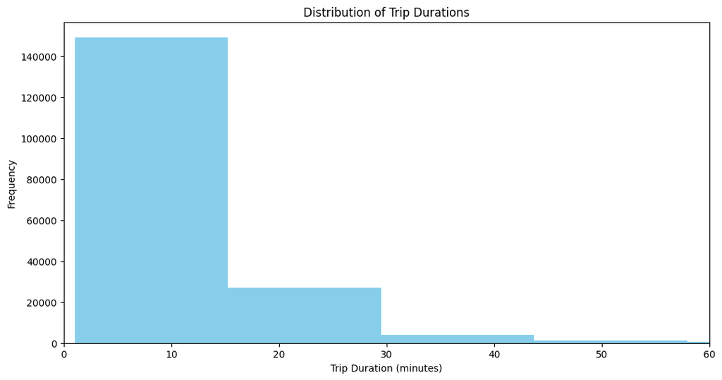

Observations: Majority of Trips are Short: The majority of trips are less than 10 minutes in duration. This indicates that the bike-sharing service is primarily used for short commutes or quick trips. Longer Trips are Rare: Trips longer than 20 minutes are rare, suggesting that users prefer the service for shorter journeys. Possible Data Anomalies: There are some very long trip durations which might indicate data entry errors or unusual use cases.

## (Visualization 2)

Distribution of Trip Start Times by Hour

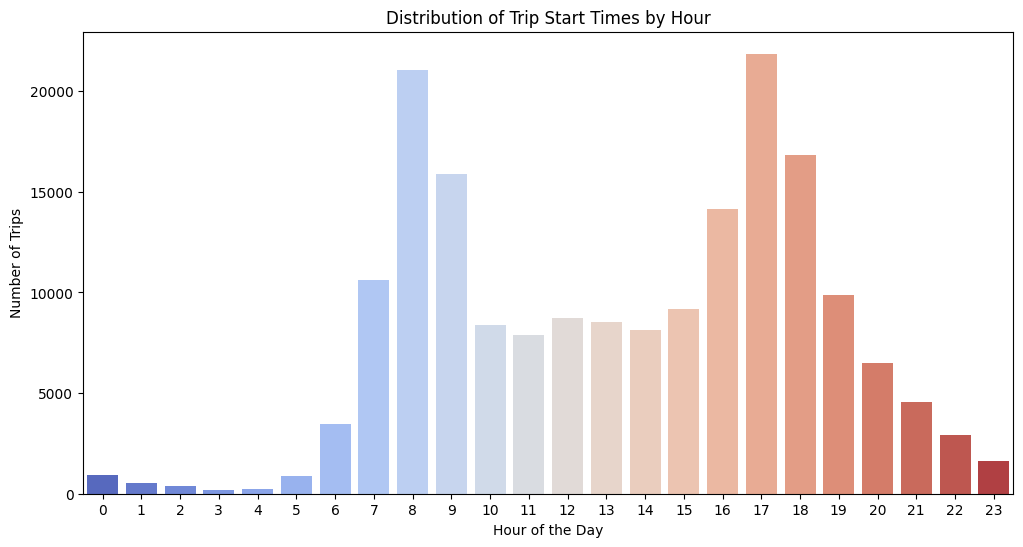

Observations: Morning Rush Hour: There is a significant peak in trip start times around 8 AM, indicating high usage during the morning rush hour. Evening Rush Hour: Another peak occurs around 5 PM, corresponding to the evening rush hour when people are likely commuting home. Low Usage Overnight: Trip start times between midnight and early morning (12 AM to 6 AM) are relatively low, indicating that the service is used less during these hours. Consistent Usage During Daytime: From 9 AM to 4 PM, there is a steady number of trips, though fewer than during the rush hours.

## (Visualization 3)Distribution of Trip Start Times by Day of the Week

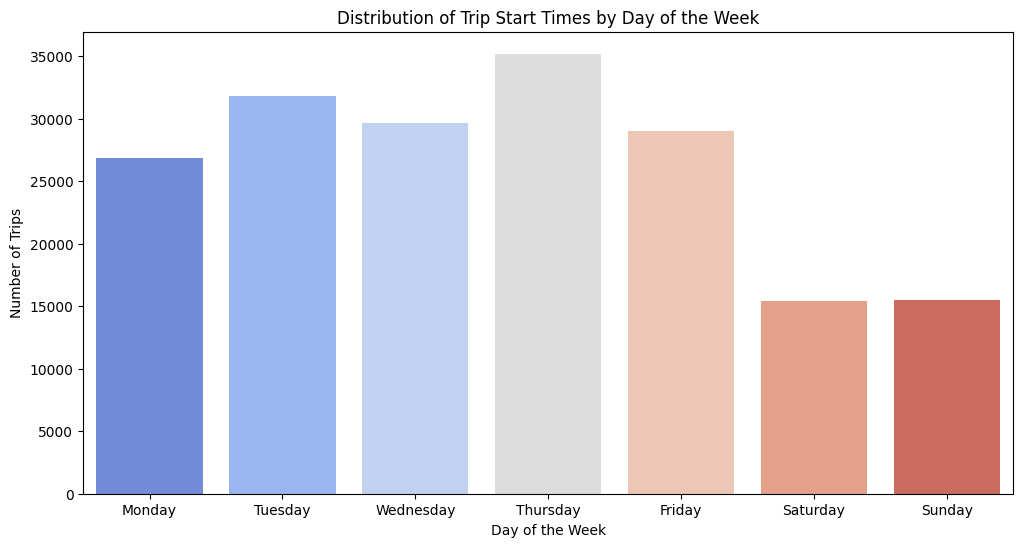

Observations: Weekday Usage: The number of trips is highest on weekdays, with a peak on Thursday. This indicates that the bike-sharing service is predominantly used by commuters. Weekend Usage: There is a noticeable drop in usage on weekends (Saturday and Sunday), suggesting that fewer people use the service for leisure activities compared to commuting. Consistent Weekday Pattern: Monday to Friday show a relatively consistent number of trips, reinforcing the pattern of regular weekday commuting

## (Visualization 2)

Slide 5: Bivariate Exploration

### Visualization 1: Trip Duration vs. Age by Gender

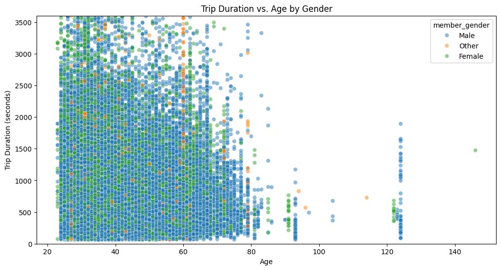

Observations: Age Distribution: Most users are between 20 and 40 years old. This is consistent with the earlier observation that younger adults are the primary users. Trip Duration: Trip durations are mostly under 1 hour across all age groups, with a dense cluster of shorter trips. Gender Differences: Both males and females show similar patterns in trip durations across different ages. There are no significant differences in trip duration between genders for the same age group. Outliers: There are some outliers with unusually high trip durations, which might need further investigation to understand if they are due to specific events or data entry errors. Add this Markdown and code block to your Jupyter Notebook to create a well-structured slide with observations for the bivariate exploration of trip duration vs. age by gender.